## Introduction to generalised linear models (GLMs)

Recall, the simple linear regression model from module 2:

$$Y_i = \alpha + \beta_1x_i + \epsilon_i$$
where

$$\epsilon_i \sim \text{Normal}(0,\sigma^2).$$

Here for observation $i$

- $Y_i$ is the value of the response
- $x_i$ is the value of the explanatory variable
- $\epsilon_i$ is the error term: the difference between $Y_i$ and its expected value
- $\alpha$ is the intercept term (a parameter to be estimated), and
- $\beta_1$ is the slope: coefficient of the explanatory variable (a parameter to be estimated)

We also saw a different specification of this model in module 3:

There is an alternative, equivalent way of specifying the linear regression model which attributes the randomness directly to the response variable rather than the error $\epsilon_i$:

$$Y_i \sim \text{Normal}(\alpha + \beta_1 x_i, \sigma^2).$$

That is, we assume the $i^{th}$ observation’s response, $Y_i$, comes from a normal distribution with mean $\mu_i = \alpha + \beta_1 x_i$ and variance $\sigma^2$.

In this case we assume that

- the $i^{th}$ observation’s response, $Y_i$, comes from a normal distribution,
- the mean of $Y_i$ is a **linear** combination of the explanatory terms,
- the variance of $Y_i$, $\sigma^2$, is the **same** for all observations, and
- that each observation’s response is **independent** of all others.

But, what if we want to be a little more flexible and move away from some of these assumptions?

## Poisson regression

We saw the Poisson distribution in module 4. There, we talked about it in terms of rates. Additionally, it is commonly used as a distribution for counts.

In summary, the Poisson distribution is a discrete distribution (of positive values only) and has $\text{Var}(Y_i) = \mu_i$ (i.e., we expect the variance to increase with the mean).

If we were to assume (as previously) that $\mu_i = \alpha + \beta_1 x_i$ then we would be allowing $\mu < 0$, which is not supported by the Poisson distribution. So, we use a link function to map between $\mu_i$ and the real number line:

$$\text{log}(\mu_i) = \alpha + \beta_1 x_i.$$

So, $\mu_i \geq 0$ and $-\infty < \text{log}(\mu_i) < \infty$; however negative the linear predictor $\alpha + \beta_1 x_i$ gets $\mu_i$ will always be positive.

Equivalently,
$$\mu_i = \text{exp}(\alpha + \beta_1 x_i)$$

and

$$Y_i \sim \text{Poisson}(\mu_i)$$

### An example: bird abundance

A recent publication [Partitioning beta diversity to untangle mechanisms underlying the assembly of bird communities in Mediterranean olive groves](https://onlinelibrary.wiley.com/doi/10.1111/ddi.13445) investigates bird abundance data for a number of olive farms. Each farm is catalogued according to the level of landscape complexity (high; intermediate; low) and the type of management of the ground cover (extensive or intensive).

```r
library(tidyverse)
data <- read_delim("https://raw.githubusercontent.com/STATS-UOA/databunker/master/data/bird_abundance.csv")
birds <- data %>%
  select(c("OliveFarm","Management","Turdus_merula","Phylloscopus_collybita")) %>%
  pivot_longer(., c(-OliveFarm, -Management), "Species", values_to = "Count")
birds
```

```
## # A tibble: 80 × 4
##    OliveFarm   Management Species                Count
##    <chr>       <chr>      <chr>                  <dbl>
##  1 MORALEDAEXP intensive  Turdus_merula             21
##  2 MORALEDAEXP intensive  Phylloscopus_collybita    14
##  3 MORALEDACON extensive  Turdus_merula             29
##  4 MORALEDACON extensive  Phylloscopus_collybita    21
##  5 OJUELOSEXP  intensive  Turdus_merula              5
##  6 OJUELOSEXP  intensive  Phylloscopus_collybita    31
##  7 OJUELOSCON  extensive  Turdus_merula             12
##  8 OJUELOSCON  extensive  Phylloscopus_collybita    52
##  9 LUNAEXP     extensive  Turdus_merula            103
## 10 LUNAEXP     extensive  Phylloscopus_collybita    10
## # … with 70 more rows
```

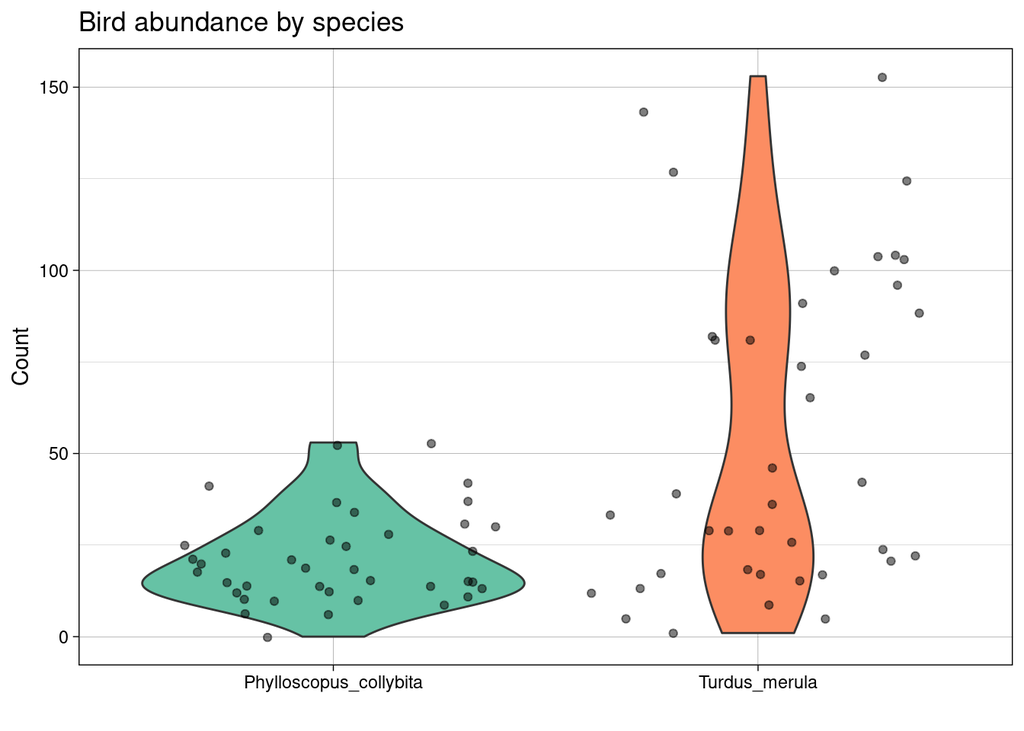

```r
glm_bird <- glm(Count ~ Species, data = birds, family = "poisson")
summary(glm_bird)
```

```
##
## Call:
## glm(formula = Count ~ Species, family = "poisson", data = birds)
##
## Deviance Residuals:
##    Min      1Q  Median      3Q     Max
## -9.994  -3.851  -1.348   2.868  10.828
##
## Coefficients:
##                      Estimate Std. Error z value Pr(>|z|)
## (Intercept)           3.06105    0.03422   89.45   <2e-16 ***
## SpeciesTurdus_merula  0.94537    0.04032   23.45   <2e-16 ***
## ---
## Signif. codes:  0 '***' 0.001 '**' 0.01 '*' 0.05 '.' 0.1 ' ' 1
##
## (Dispersion parameter for poisson family taken to be 1)
##
##     Null deviance: 2234.6  on 79  degrees of freedom
## Residual deviance: 1621.9  on 78  degrees of freedom
## AIC: 2030.1
##
## Number of Fisher Scoring iterations: 5
```

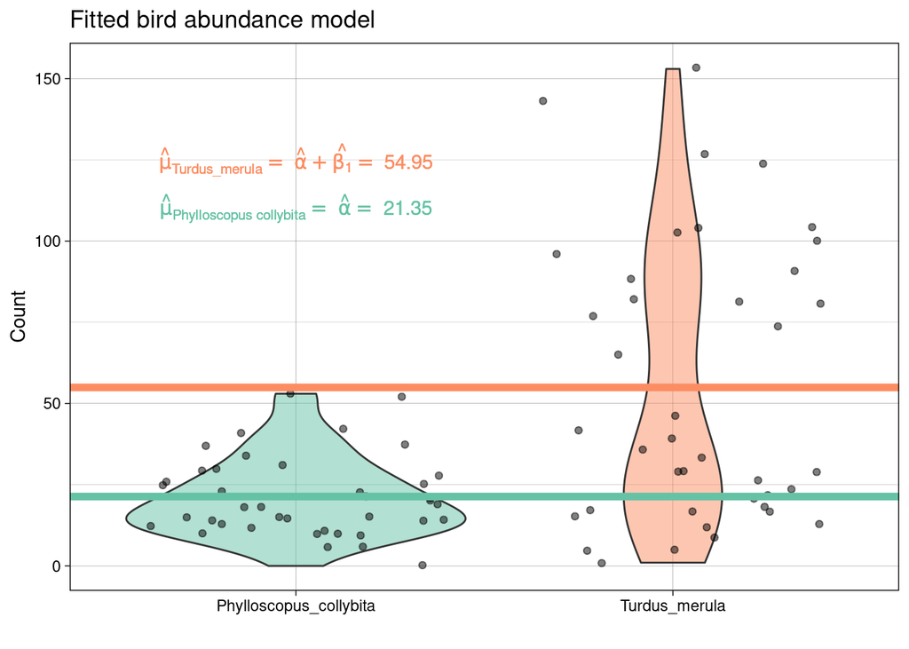

## Logistic regression

We saw the Binomial distribution in module 4. We define a random variable, $Y_i$, to have a binomial distribution if it is the number of successes from a number of **independent** trials, $n$, each with the same probability of success, $p$. It is a discrete distribution, which notes that the number of successes associated with the $i^{th}$ observation must be an integer between $0$ and $n_i$. In addition, it builds in the non-constant variance of $Y_i$ and $\frac{Y_i}{n_i}$:

- $\text{Var}(Y_i)=n_ip_i(1−p_i)$
- $\text{Var}(\frac{Y_i}{n_i}) = \frac{p_i(1−p_i)}{n_i}$

If we were to assume a linear relationship (as previously) that $p_i = \alpha + \beta_1 x_i$ then we would be allowing $p < 0$ and $p>1$, which is not supported by the binomial distribution. So, we use a link function to map between $p$ and the real number line:

$$\text{logit}(p_i) = \text{log}\left (\frac{p_i}{1 - p_i}\right ) = \alpha + \beta_1x_i.$$
This leads to
$$p_i = \frac{\exp(\alpha + \beta_1x_i)}{1 + \exp(\alpha + \beta_1x_i)}.$$
and

$$Y_i \sim \text{Binomial}(n_i, p_i)$$

### An example: lobsters

Let us, again, consider data from the published article [Influence of predator identity on the strength of predator avoidance responses in lobsters.](https://www.sciencedirect.com/science/article/pii/S0022098115000039).

The authors were interested in how a juvenile lobster’s size was related to its vulnerability to predation. In total, 159 juvenile lobsters were collected from their natural habitat in the Gulf of Maine, USA, and the length of each lobster’s carapace (upper shell) was measured to the nearest 3 mm, `size`. The lobsters were then tethered to the ocean floor for 24 hours. Any missing lobsters were assumed to have been consumed by a predator, while the surviving lobsters were released (i.e., `survived` = 1 if lobster survived, 0 otherwise).

```r
library(tidyverse)
data <- read_csv("https://raw.githubusercontent.com/STATS-UOA/databunker/master/data/lobster.csv")
data
```

```
## # A tibble: 159 × 2
##     size survived
##    <dbl>    <dbl>
##  1    42        0
##  2    36        0
##  3    51        1
##  4    33        0
##  5    33        1
##  6    45        1
##  7    54        1
##  8    48        0
##  9    39        0
## 10    48        1
## # … with 149 more rows
```

#### Ungrouped model

Fitting a binomial model we specify `family = "binomial"` in our `glm` call. Note that the default link function for `family = "binomial"` is the logit link; we could also use the equivalent syntax `binomial(link = logit)`to specify this model.

```r
glm_mod_ug <- glm(survived ~ size, family = "binomial", data = data)
summary(glm_mod_ug)
```

```
##
## Call:
## glm(formula = survived ~ size, family = "binomial", data = data)
##
## Deviance Residuals:
##     Min       1Q   Median       3Q      Max
## -2.1019  -0.8454  -0.3771   0.9304   2.0711
##
## Coefficients:
##             Estimate Std. Error z value Pr(>|z|)
## (Intercept) -7.89597    1.38501  -5.701 1.19e-08 ***
## size         0.19586    0.03415   5.735 9.77e-09 ***
## ---
## Signif. codes:  0 '***' 0.001 '**' 0.01 '*' 0.05 '.' 0.1 ' ' 1
##
## (Dispersion parameter for binomial family taken to be 1)
##
##     Null deviance: 220.41  on 158  degrees of freedom
## Residual deviance: 172.87  on 157  degrees of freedom
## AIC: 176.87
##
## Number of Fisher Scoring iterations: 4
```

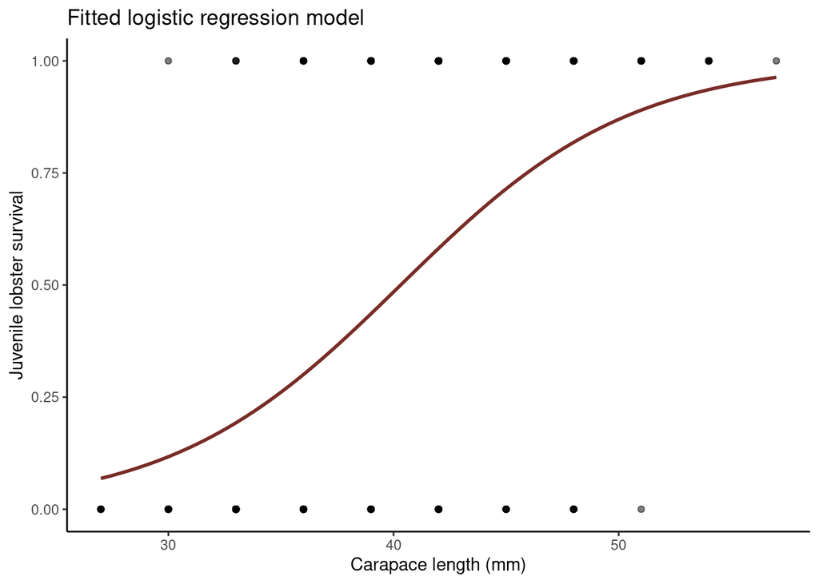

#### Grouped model

The data are currently ungrouped, despite many lobsters sharing the same carapace size. Therefore, we rearrange the data set so that it is grouped:

```r
grouped <- data %>%
  group_by(size) %>%
  summarise(y = sum(survived), n = length(survived), p = mean(survived))
grouped
```

```
## # A tibble: 11 × 4
##     size     y     n     p
##    <dbl> <dbl> <int> <dbl>
##  1    27     0     5 0
##  2    30     1    10 0.1
##  3    33     3    22 0.136
##  4    36     7    21 0.333
##  5    39    12    22 0.545
##  6    42    17    29 0.586
##  7    45    13    18 0.722
##  8    48    12    17 0.706
##  9    51     7     8 0.875
## 10    54     6     6 1
## 11    57     1     1 1
```

Where,

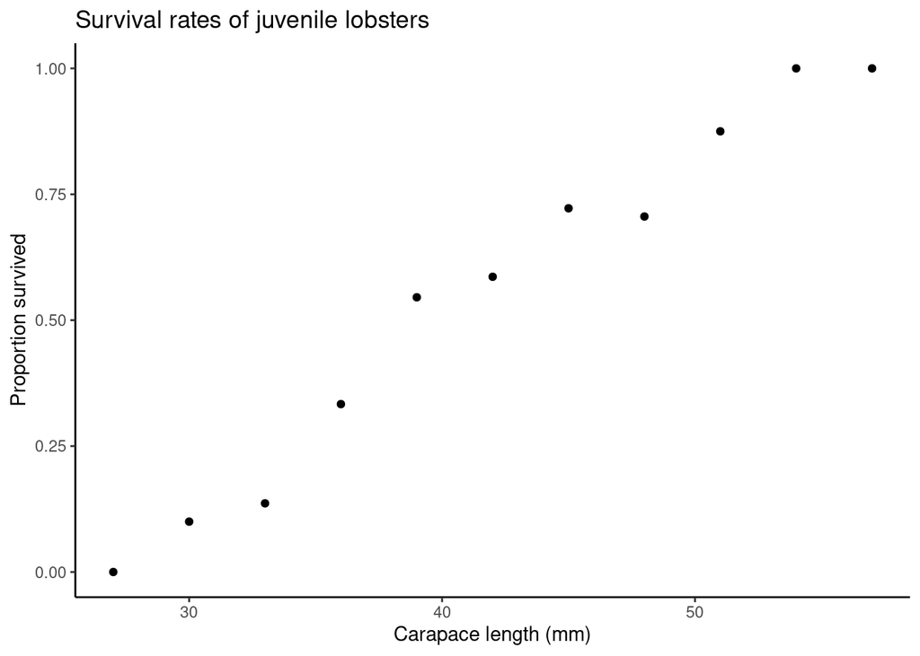

Fitting a binomial model again we specify `family = "binomial"` in our `glm` call and specify our response as `cbind(y, n - y)`:

```r
glm_mod_gr <- glm(cbind(y, n - y) ~ size, family = "binomial", data = grouped)
summary(glm_mod_gr)
```

```
##
## Call:
## glm(formula = cbind(y, n - y) ~ size, family = "binomial", data = grouped)
##
## Deviance Residuals:
##      Min        1Q    Median        3Q       Max
## -1.12729  -0.43534   0.04841   0.29938   1.02995
##
## Coefficients:
##             Estimate Std. Error z value Pr(>|z|)
## (Intercept) -7.89597    1.38501  -5.701 1.19e-08 ***
## size         0.19586    0.03415   5.735 9.77e-09 ***
## ---
## Signif. codes:  0 '***' 0.001 '**' 0.01 '*' 0.05 '.' 0.1 ' ' 1
##
## (Dispersion parameter for binomial family taken to be 1)
##
##     Null deviance: 52.1054  on 10  degrees of freedom
## Residual deviance:  4.5623  on  9  degrees of freedom
## AIC: 32.24
##
## Number of Fisher Scoring iterations: 4
```

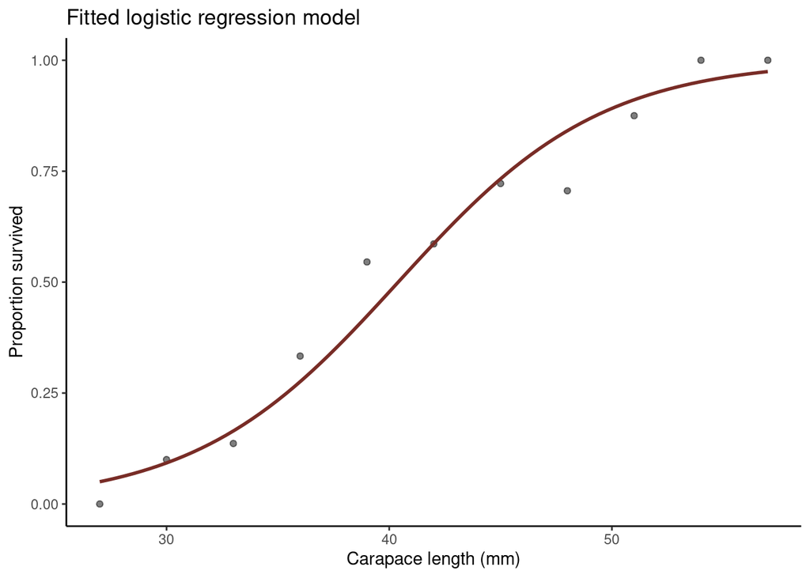

## A summary of GLMs

The three distributions we’ve covered are given below.

**Linear regression:** $Y_i \sim \text{Normal}(\mu_i, \sigma^2)$ where $\mu_i = \alpha + \beta_1 x_i$

**Poisson regression:** $Y_i \sim \text{Poisson}(\mu_i)$ where $\text{log}(\mu_i) = \alpha + \beta_1 x_i$

**Logistic regression:** $Y_i \sim \text{Binomial}(n_i, p_i)$ where $\text{logit}(p_i) = \alpha + \beta_1 x_i$

What would happen if we wanted to add extra explanatory terms (e.g., $z_i$)? Then,

**Linear regression:** $Y_i \sim \text{Normal}(\mu_i, \sigma^2)$ where $\mu_i = \alpha + \beta_1 x_i + \beta_2 z_i$

**Poisson regression:** $Y_i \sim \text{Poisson}(\mu_i)$ where $\text{log}(\mu_i) = \alpha + \beta_1 x_i+ \beta_2 z_i$

**Logistic regression:** $Y_i \sim \text{Binomial}(n_i, p_i)$ where $\text{logit}(p_i) = \alpha + \beta_1 x_i+ \beta_2 z_i$

What about interactions (e.g., $x_iz_i$)? then,

**Linear regression:** $Y_i \sim \text{Normal}(\mu_i, \sigma^2)$ where $\mu_i = \alpha + \beta_1 x_i + \beta_2 z_i + \beta_3 x_iz_i$

**Poisson regression:** $Y_i \sim \text{Poisson}(\mu_i)$ where $\text{log}(\mu_i) = \alpha + \beta_1 x_i+ \beta_2 z_i + \beta_3 x_iz_i$

**Logistic regression:** $Y_i \sim \text{Binomial}(n_i, p_i)$ where $\text{logit}(p_i) = \alpha + \beta_1 x_i+ \beta_2 z_i + \beta_3 x_iz_i$

**An example**

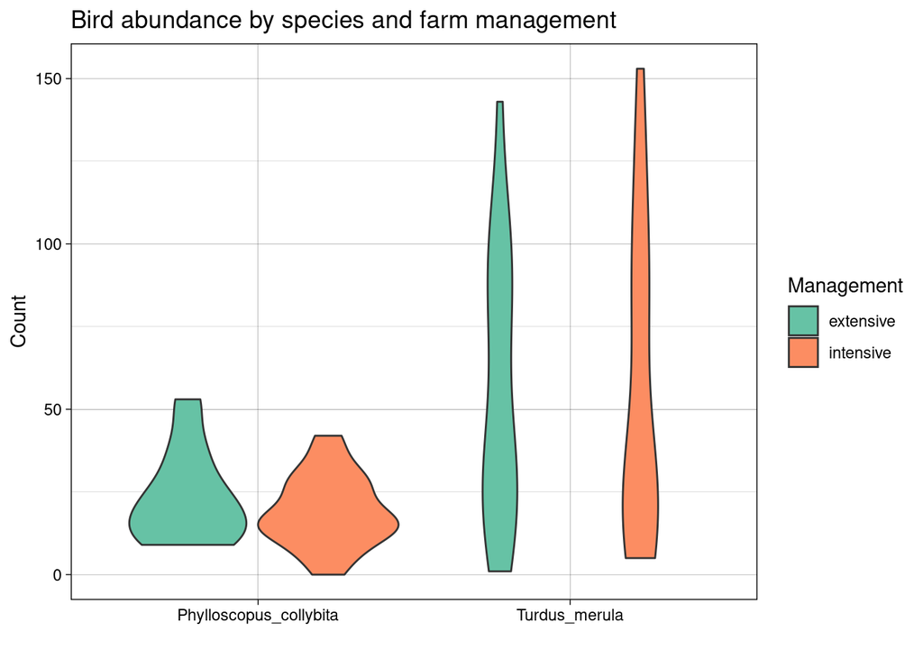

```r
glm_bird_int <- glm(Count ~ Species*Management, data = birds, family =  "poisson")
summary(glm_bird_int)
```

```
##
## Call:
## glm(formula = Count ~ Species * Management, family = "poisson",
##     data = birds)
##
## Deviance Residuals:
##     Min       1Q   Median       3Q      Max
## -10.043   -3.537   -1.008    2.652   10.911
##
## Coefficients:
##                                          Estimate Std. Error z value Pr(>|z|)
## (Intercept)                               3.15487    0.04618  68.323  < 2e-16
## SpeciesTurdus_merula                      0.86061    0.05508  15.624  < 2e-16
## Managementintensive                      -0.19736    0.06877  -2.870  0.00411
## SpeciesTurdus_merula:Managementintensive  0.17916    0.08093   2.214  0.02684
##
## (Intercept)                              ***
## SpeciesTurdus_merula                     ***
## Managementintensive                      **
## SpeciesTurdus_merula:Managementintensive *
## ---
## Signif. codes:  0 '***' 0.001 '**' 0.01 '*' 0.05 '.' 0.1 ' ' 1
##
## (Dispersion parameter for poisson family taken to be 1)
##
##     Null deviance: 2234.6  on 79  degrees of freedom
## Residual deviance: 1613.5  on 76  degrees of freedom
## AIC: 2025.6
##
## Number of Fisher Scoring iterations: 5
```

**Building a GLM**

Assume the observations are independent of one another, then,

1. Choose a distribution for the response. For example, Normal, Poisson, or Binomial.
2. Choose a parameter to relate to explanatory terms. For example, $\mu_i$, $\mu_i$, or $p_i$.
3. Choose a link function. For example, identity, log, or logit.
4. Choose explanatory terms
5. Estimate additional parameters. For example, $\sigma^2$.

We are not restricted to the three distributions above. Many others exist:

- Gamma and inverse-Gaussian, for continuous responses on the interval $[0,\infty)$
- Beta, for continuous responses on the interval $[0,1]$
- Negative binomial, for discrete responses on $(0,1,2,\cdots)$, with $\text{Var}(Y) \geq E(Y)$
- …